# Analiza zużycia energii i jak wpływa na śmiertelność w latach 2010-2018

Tomasz Król

2026-01-31

# WSTĘP

Badanie ma na celu analizę wskaźnika śmiertelności związanej z zanieczyszczenie powietrza z perspektywy zarówno kontynentalnej jak i krajowej, uwzględniając podział na płeć oraz czynniki ekonomiczno-energetyczne. Sprawdzona zostanie zależność między liczbą zgonów a sposobem wytwarzania energii elektrycznej (tzw. miksem energetycznym), intensywnością emisji CO2 przy produkcji prądu oraz PKB per capita. Wnioski oparte są na podstawie przefiltrowanych i połączonych danych z lat 2010–2018, analizy wykresów rozrzutu oraz porównania krajów o skrajnych wskaźnikach śmiertelności. Analiza sprawdza wpływ energii wytwarzanie przy użyciu węgiela, ropy na zdrowie publiczne oraz weryfikuje hipotezę, czy wysoki wzrost gospodarczy jest czynnikiem niwelującym skutki zanieczyszczeń.

# Śmiertelność:

country - kraj  
year - rok  
sex - płeć; podział na mężczyzn i kobiety oraz sume(“Both sexes”)  
śmierci - liczba zgonów  
zgony_na_100k - wskaźnik śmiertelności na 100 mieszkańców (śmierci w ciągu roku/populacja)*100000  
źródło: https://www.who.int/data/gho/data/indicators/indicator-details/GHO/ambient-air-pollution-attributable-deaths

# World Energy Consumption

country - kraj  
year - rok  
Code - kod państwa  
population - populacja  
gdp - PKB  
primary_energy_consumption - całkowite_zużycie_energii  
energy_per_capita - zużycie_energii_per_capita  
carbon_intensity_elec - intensywność_dwutlenku_produkując_prąd  
greenhouse_gas_emissions - emisje_gazów_cieplarnianych  
źródło: https://www.kaggle.com/datasets/pralabhpoudel/world-energy-consumption

# Share-electricity-coal

country - kraj  
code - kod państwa  
year - rok  
Coal electricity - udział węgla w produkcji prądu  
źródło: https://ourworldindata.org/grapher/share-electricity-coal

# Share-electricity-gas

country - kraj  
code - kod państwa  
year - rok  
Gas electricity - udział gazu w produkcji prądu  
źródło: https://ourworldindata.org/grapher/share-electricity-gas?tab=discrete-bar&time=latest

# Share-electricity-oil

country - kraj  
code - kod państwa  
year - rok  
Oil electricity - udział ropy w produkcji prądu  
źródło: https://ourworldindata.org/grapher/share-electricity-oil?time=2013

# Share-electricity-nuclear

country - kraj  
code - kod państwa  
year - rok  
Nuclear electricity - udział ropy w produkcji prądu  
źródło: https://ourworldindata.org/grapher/share-electricity-nuclear

# Share-of-electricity-production-from-renewable-sources

country - kraj  
code - kod państwa  
year - rok  
renewableshare electricity - udział odnawialnych źródeł energii w produkcji prądu  
źródło: https://ourworldindata.org/grapher/share-of-electricity-production-from-renewable-sources?tab=map&time=2016

# Country-by-continents

contynent - kontynent  
country - kraj  
źródło: https://www.kaggle.com/datasets/hserdaraltan/countries-by-continent?resource=download

# Pytania badawcze

1. Na którym kontynencie wskaźnik śmiertelności jest najwyższy, a na którym najniższy?
2. Czy płeć ma znaczenie? Jak wygląda rozkład zgonów i różnice między kobietami a mężczyznami w skali globalnej i kontynentalnej?
3. W których państwach ginie najwięcej ludzi, a które są najbezpieczniejsze?
4. Jak zmieniał się wskaźnik śmiertelności na przestrzeni badanych lat (2010–2018) w ujęciu kontynentalnym?
5. Czy istnieje zależność między zamożnością kraju (PKB per capita) a śmiertelnością?
6. Co jest największym zabójcą?

6a. Czy OZE zawsze gwarantuje zdrowie?

6b. Czy węgiel uznawany za brudną energię jest w rzeczywistości trucicielem?

# Biblioteki

```r
library(tidyverse)
library(nortest)
library(knitr)
library(scales)
library(patchwork)
```

# Wczytanie danych

```r
df_śmierci <- read.csv("dane_śmierci.csv")
df_energia_PKB_mix_zanieczyszczenie <- read.csv("World_Energy_Consumption.csv")
df_countries_by_continents <- read.csv("Countries by continents.csv")
df_coal_share <- read.csv("share-electricity-coal.csv")
df_gas_share <- read.csv("share-electricity-gas.csv")
df_nuclear_share <- read.csv("share-electricity-nuclear.csv")
df_oil_share <- read.csv("share-electricity-oil.csv")
df_renewableresources_share <- read.csv("share-of-electricity-production-from-renewable-sources.csv")
```

# Wybór potrzebnych kolumn

```r
dane_śmierci <- df_śmierci%>%
  select(kraj = Location, rok = Period, płeć = Dim1, choroba = Dim2, śmierci = FactValueNumeric)

dane_surowe <- df_energia_PKB_mix_zanieczyszczenie %>%
  select(kraj_region_organizacja = country, kod = iso_code, rok = year, populacja = population, PKB = gdp, całkowite_zużycie_energii = primary_energy_consumption, zużycie_energii_per_capita = energy_per_capita, udział_węgla = coal_share_energy, udział_ropy = oil_share_energy, udział_gazu = gas_share_energy, udział_źródeł_odnawialnych = renewables_share_energy, udział_atomu = nuclear_share_energy, intensywność_dwutlenku_produkując_prąd = carbon_intensity_elec, emisje_gazów_cieplarnianych  = greenhouse_gas_emissions)
```

# Wstępne czyszczenie danych

```r
df_countries_by_continents <- na.omit(df_countries_by_continents)
df_coal_share <- na.omit(df_coal_share)
df_gas_share <- na.omit(df_gas_share)
df_nuclear_share <- na.omit(df_nuclear_share)
df_oil_share <- na.omit(df_oil_share)
df_renewableresources_share <- na.omit(df_renewableresources_share)
kraje_i_kontynenty <- na.omit(df_countries_by_continents)
```

# Filtrowanie danych i tworzenie potrzebnych kolumn

```r
kraje_i_kontynenty <- kraje_i_kontynenty%>%
  rename(kontynent = Continent, kraj = Country)

dane_śmierci <- df_śmierci%>%
  select(kraj = Location, rok = Period, płeć = Dim1, choroba = Dim2, śmierci = FactValueNumeric)%>%
  filter(choroba == "All causes")

dane_surowe <- df_energia_PKB_mix_zanieczyszczenie %>%
  select(Entity = country, Code = iso_code, Year = year, populacja = population, PKB = gdp,  całkowite_zużycie_energii = primary_energy_consumption, zużycie_energii_per_capita = energy_per_capita, intensywność_dwutlenku_produkując_prąd = carbon_intensity_elec, emisje_gazów_cieplarnianych  = greenhouse_gas_emissions)

dane <- dane_surowe %>%
  left_join(df_coal_share, by = c("Entity", "Year", "Code"))

dane <- dane %>%
  left_join(df_gas_share, by = c("Entity", "Year", "Code"))

dane <- dane %>%
  left_join(df_nuclear_share, by = c("Entity", "Year", "Code"))

dane <- dane %>%
  left_join(df_oil_share, by = c("Entity", "Year", "Code"))

dane <- dane %>%
  left_join(df_renewableresources_share, by = c("Entity", "Year", "Code"))%>%
  filter(Year >2009 & Year<2019)%>%
  rename(kraj = Entity, rok = Year)

poprawki_krajow <- c("United States of America" = "United States",
  "Russian Federation" = "Russia",
  "United Kingdom of Great Britain and Northern Ireland" = "United Kingdom",
  "Iran (Islamic Republic of)" = "Iran",
  "Venezuela (Bolivarian Republic of)" = "Venezuela")

dane_śmierci <- df_śmierci%>%
  select(kraj = Location, rok = Period, płeć = Dim1, choroba = Dim2, śmierci = FactValueNumeric)%>%
  filter(choroba == "All causes")%>%
  mutate(kraj = str_replace_all(kraj, poprawki_krajow))

dane_kraje <- dane%>%
  filter(Code != "", PKB>0, całkowite_zużycie_energii !=0)%>%
  right_join(kraje_i_kontynenty, by = c("kraj"))%>%
  relocate(kontynent, .before = 1)%>%
  mutate(PKB_per_capita = PKB/populacja)


dane_kraje <- dane_kraje%>%
  rename(udział_węgla = Coal.....electricity, udział_gazu = Gas.....electricity, udział_ropy = Oil.....electricity, udział_źródeł_odnawialnych = Renewables.....electricity, udział_atomu = Nuclear.....electricity)


dane_kompletne <- dane_kraje%>%
  left_join(dane_śmierci, by = c("kraj", "rok"))%>%
  mutate(zgony_na_100k = (śmierci / populacja) * 100000)


dane_kompletne <- dane_kompletne%>%
  filter(kontynent != "Oceania")
```

# Ponowne czyszczenie danych

```r
dane_kompletne <- na.omit(dane_kompletne)
```

# Zdefiniowanie kolorów kontynentów i pomocniczych wektorów

```r
continent_colors <- c(
  "Europe" = "#0092db",
  "Asia" = "#ffd428",
  "Africa" = "#141414",
  "Oceania" = "#ff6314",
  "North America" = "#f90028",
  "South America" = "#00d251")

źródła_colors <- c(
  "udział_węgla" = "#808080",
  "udział_ropy" = "#b96161",
  "udział_gazu" = "#79d1ff",
  "udział_atomu" = "#dda0dd",
  "udział_źródeł_odnawialnych" = "#76d599")

źródła_udział <- c("udział_węgla", "udział_ropy", "udział_gazu", "udział_atomu", "udział_źródeł_odnawialnych")
```

# Zapoznanie się z danymi

```r
str(dane_kompletne)
```

```
## 'data.frame':    3714 obs. of  20 variables:
##  $ kontynent                             : chr  "Asia" "Asia" "Asia" "Asia" ...
##  $ kraj                                  : chr  "Afghanistan" "Afghanistan" "Afghanistan" "Afghanistan" ...
##  $ Code                                  : chr  "AFG" "AFG" "AFG" "AFG" ...
##  $ rok                                   : int  2010 2010 2010 2011 2011 2011 2012 2012 2012 2013 ...
##  $ populacja                             : num  28189672 28189672 28189672 29249156 29249156 ...
##  $ PKB                                   : num  4.74e+10 4.74e+10 4.74e+10 5.33e+10 5.33e+10 ...
##  $ całkowite_zużycie_energii             : num  33.3 33.3 33.3 42 42 ...
##  $ zużycie_energii_per_capita            : num  1183 1183 1183 1436 1436 ...
##  $ intensywność_dwutlenku_produkując_prąd: num  160 160 160 179 179 ...
##  $ emisje_gazów_cieplarnianych           : num  0.15 0.15 0.15 0.14 0.14 0.14 0.12 0.12 0.12 0.17 ...
##  $ udział_węgla                          : num  6.82 6.82 6.82 12.99 12.99 ...
##  $ udział_gazu                           : num  0 0 0 0 0 0 0 0 0 0 ...
##  $ udział_atomu                          : num  0 0 0 0 0 0 0 0 0 0 ...
##  $ udział_ropy                           : num  7.95 7.95 7.95 9.09 9.09 ...
##  $ udział_źródeł_odnawialnych            : num  85.2 85.2 85.2 77.9 77.9 ...
##  $ PKB_per_capita                        : num  1681 1681 1681 1823 1823 ...
##  $ płeć                                  : chr  "Female" "Male" "Both sexes" "Male" ...
##  $ choroba                               : chr  "All causes" "All causes" "All causes" "All causes" ...
##  $ śmierci                               : num  10143 11063 21206 10761 20678 ...
##  $ zgony_na_100k                         : num  36 39.2 75.2 36.8 70.7 ...
##  - attr(*, "na.action")= 'omit' Named int [1:218] 379 380 381 382 383 384 385 386 387 388 ...
##   ..- attr(*, "names")= chr [1:218] "379" "380" "381" "382" ...
```

```r
summary(dane_kompletne)
```

```
##   kontynent             kraj               Code                rok
##  Length:3714        Length:3714        Length:3714        Min.   :2010
##  Class :character   Class :character   Class :character   1st Qu.:2012
##  Mode  :character   Mode  :character   Mode  :character   Median :2014
##                                                           Mean   :2014
##                                                           3rd Qu.:2016
##                                                           Max.   :2018
##    populacja              PKB            całkowite_zużycie_energii
##  Min.   :9.242e+04   Min.   :5.444e+08   Min.   :    0.563
##  1st Qu.:3.837e+06   1st Qu.:2.745e+10   1st Qu.:   29.645
##  Median :9.866e+06   Median :9.044e+10   Median :   99.454
##  Mean   :4.741e+07   Mean   :6.696e+11   Mean   :  986.594
##  3rd Qu.:3.045e+07   3rd Qu.:3.981e+11   3rd Qu.:  469.574
##  Max.   :1.417e+09   Max.   :1.815e+13   Max.   :38415.930
##  zużycie_energii_per_capita intensywność_dwutlenku_produkując_prąd
##  Min.   :   130.9           Min.   :  0.0
##  1st Qu.:  3494.5           1st Qu.:224.2
##  Median : 16394.9           Median :429.6
##  Mean   : 28131.3           Mean   :401.9
##  3rd Qu.: 34520.5           3rd Qu.:578.1
##  Max.   :245271.8           Max.   :810.3
##  emisje_gazów_cieplarnianych  udział_węgla     udział_gazu
##  Min.   :   0.00             Min.   :  0.00   Min.   :  0.000
##  1st Qu.:   0.69             1st Qu.:  0.00   1st Qu.:  0.000
##  Median :   4.42             Median :  0.00   Median :  6.931
##  Mean   :  72.75             Mean   : 13.47   Mean   : 23.093
##  3rd Qu.:  25.12             3rd Qu.: 16.68   3rd Qu.: 38.078
##  Max.   :4085.99             Max.   :100.00   Max.   :100.000
##   udział_atomu     udział_ropy       udział_źródeł_odnawialnych
##  Min.   : 0.000   Min.   :  0.0000   Min.   :  0.000
##  1st Qu.: 0.000   1st Qu.:  0.7403   1st Qu.:  5.647
##  Median : 0.000   Median :  5.2440   Median : 23.133
##  Mean   : 4.931   Mean   : 23.6561   Mean   : 34.847
##  3rd Qu.: 0.000   3rd Qu.: 38.7218   3rd Qu.: 60.193
##  Max.   :77.934   Max.   :100.0000   Max.   :100.000
##  PKB_per_capita       płeć             choroba             śmierci
##  Min.   :   610   Length:3714        Length:3714        Min.   :1.312e+01
##  1st Qu.:  3641   Class :character   Class :character   1st Qu.:8.809e+02
##  Median : 12366   Mode  :character   Mode  :character   Median :2.771e+03
##  Mean   : 18295                                         Mean   :1.889e+04
##  3rd Qu.: 23913                                         3rd Qu.:8.584e+03
##  Max.   :166150                                         Max.   :1.326e+06
##  zgony_na_100k
##  Min.   :  2.669
##  1st Qu.: 16.433
##  Median : 26.097
##  Mean   : 33.570
##  3rd Qu.: 41.754
##  Max.   :176.125
```

## 1. Na którym kontynencie wskaźnik śmiertelności jest najwyższy, a na którym najniższy?

```r
dane_kompletne%>%
  group_by(kontynent, płeć)%>%
  summarise(srednia_zgonow = round(mean(zgony_na_100k),2))%>%
  filter(płeć == "Both sexes")%>%
  kable()
```

| kontynent | płeć | srednia_zgonow |
| --- | --- | --- |
| Africa | Both sexes | 39.01 |
| Asia | Both sexes | 50.20 |
| Europe | Both sexes | 76.47 |
| North America | Both sexes | 29.55 |
| South America | Both sexes | 29.10 |

Najwyższy wskaźnik śmiertelnośći dla obu płci osiągneła Europa, który wynosi 76.47. Świadczy to, że średnio na 100tyś. osób co roku umiera 76 osób na choroby, które są skutkiem zanieczyszenia powietrza. Najniższy współczynnik dla obu płci widzimy w Ameryce Południowej.

## 2. Jak zmieniał się wskaźnik śmiertelności na przestrzeni badanych lat w ujęciu kontynentalnym?

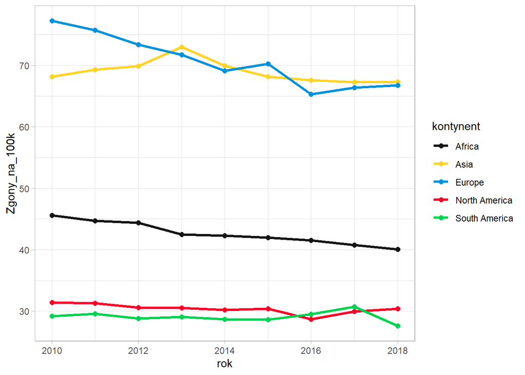

```r
dane_kompletne %>%
  filter(płeć == "Both sexes")%>%
  group_by(kontynent, rok)%>%
  summarise(Calkowita_Populacja = sum(populacja, na.rm = TRUE), Calkowita_Liczba_Zgonow = sum(śmierci, na.rm = TRUE))%>%
  mutate(Zgony_na_100k = (Calkowita_Liczba_Zgonow / Calkowita_Populacja) * 100000)%>%
  ggplot(aes(x = rok, y = Zgony_na_100k, color = kontynent))+
  geom_line(size = 1.2)+
  geom_point(size = 2)+
  scale_colour_manual(values = continent_colors)+
  scale_x_continuous(limits = c(2010, 2018), breaks = seq(2010, 2018, 2))+
  scale_y_continuous(labels = label_number(accuracy = 1))+
  theme_light()
```

Na tym wykresie możemy zobaczyć w czasie jednak ten wskaźnik się zmieniał wszczególności dla Europy i Azji. Widzimy tu jak wskaźnik Europy zmalał aż do poziomu Azji. Można zauważy również jak bezpieczne pod tym kątem są obie Ameryki.

## 3. Czy płeć ma znaczenie? Jak wygląda rozkład zgonów i różnice między kobietami a mężczyznami w skali globalnej i kontynentalnej?

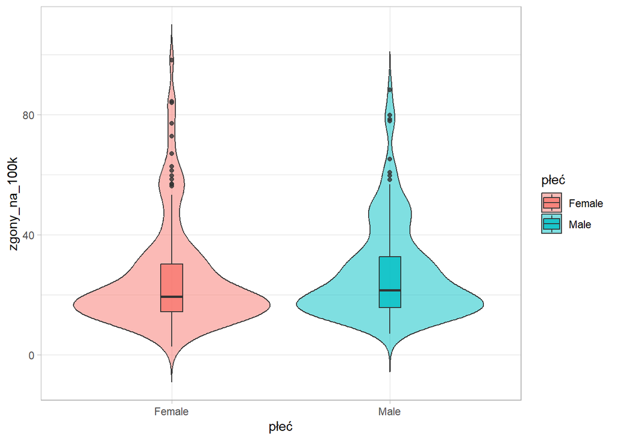

```r
dane_kompletne%>%
  filter(rok == 2010, !płeć =="Both sexes")%>%
  ggplot(aes(x = płeć, y = zgony_na_100k, fill = płeć))+
  geom_violin(alpha = 0.5, trim = F)+
  geom_boxplot(width = 0.1, alpha = 0.8)+
  theme_light()
```

Zarówno u kobiet, jak i u mężczyzn, większość danych koncentruje się w dolnej części skali, co widać w okolicach 20 zgonów na 100k. Medianadla obu płciznajduje się na zbliżonym poziomie. W przypadku kobiet widać nieco więcej skrajnie wysokich punktów powyżej poziomu 80 niż u mężczyzn.

```r
dane_kompletne%>%
  group_by(kontynent, płeć)%>%
  summarise(srednia_zgonow = round(mean(zgony_na_100k),2))%>%
  kable()
```

| kontynent | płeć | srednia_zgonow |
| --- | --- | --- |
| Africa | Both sexes | 39.01 |
| Africa | Female | 18.38 |
| Africa | Male | 20.63 |
| Asia | Both sexes | 50.20 |
| Asia | Female | 22.18 |
| Asia | Male | 28.02 |
| Europe | Both sexes | 76.47 |
| Europe | Female | 39.33 |
| Europe | Male | 37.14 |
| North America | Both sexes | 29.55 |
| North America | Female | 14.21 |
| North America | Male | 15.34 |
| South America | Both sexes | 29.10 |
| South America | Female | 14.00 |
| South America | Male | 15.09 |

Natomiast analizując poszczególne kontynenty to najwięcej umiera mężczyzn (37.14) i kobiet (39.33) w Europie, a najmniej w Ameryce Południowej. Widzimy, że tylko w Europie średnia liczba śmierci kobiet przewyższa liczbe śmierci mężczyzn.

## 4. W których państwach ginie najwięcej ludzi, a które są najbezpieczniejsze?

```r
dane_kompletne%>%
  filter(płeć == "Both sexes")%>%
  group_by(kraj)%>%
  summarise(mean_country_death = round(mean(zgony_na_100k),2))%>%
  top_n(10)%>%
  arrange(desc(mean_country_death))%>%
  kable()
```

| kraj | mean_country_death |
| --- | --- |
| Bulgaria | 165.02 |
| Ukraine | 153.84 |
| Georgia | 150.58 |
| Belarus | 144.13 |
| Serbia | 124.90 |
| Montenegro | 118.56 |
| Latvia | 118.48 |
| Armenia | 118.29 |
| Romania | 117.67 |
| Lithuania | 113.49 |

Najwyższy wskaźnik śmiertelności dla obu płci osiąga Bułgarii (165.02), co oznacza, że średnio co roku w Bułgarii umiera 165 osób na 100tyś. ze wzgledu na choroby spowodowane zły powietrzem.

```r
dane_kompletne%>%
  filter(płeć == "Both sexes")%>%
  group_by(kraj)%>%
  summarise(mean_country_death = round(mean(zgony_na_100k),2))%>%
  head(10)%>%
  arrange(mean_country_death)%>%
  kable()
```

| kraj | mean_country_death |
| --- | --- |
| Bahrain | 23.49 |
| Angola | 32.80 |
| Algeria | 37.60 |
| Argentina | 42.60 |
| Bangladesh | 44.67 |
| Austria | 57.19 |
| Afghanistan | 65.26 |
| Albania | 77.26 |
| Azerbaijan | 102.51 |
| Armenia | 118.29 |

Różnica między średnimi jest widoczna zatem przeprowadze test aby sprawdzić czy jest ona statystycznie istotna.

Hipotezy: H0: m1 = m2 H1: m1 > m2

```r
zgony_Austria <- dane_kompletne %>%
  filter(płeć == "Both sexes", kraj =="Austria")%>%
  pull(zgony_na_100k)

shapiro.test(zgony_Austria)
```

```
##
##  Shapiro-Wilk normality test
##
## data:  zgony_Austria
## W = 0.89137, p-value = 0.2061
```

```r
zgony_Albania <- dane_kompletne %>%
  filter(płeć == "Both sexes", kraj =="Albania")%>%
  pull(zgony_na_100k)

shapiro.test(zgony_Albania)
```

```
##
##  Shapiro-Wilk normality test
##
## data:  zgony_Albania
## W = 0.90432, p-value = 0.2781
```

```r
t.test(x = zgony_Austria, y = zgony_Albania, alternative = "greater")
```

```
##
##  Welch Two Sample t-test
##
## data:  zgony_Austria and zgony_Albania
## t = -3.8901, df = 9.1662, p-value = 0.9982
## alternative hypothesis: true difference in means is greater than 0
## 95 percent confidence interval:
##  -29.5137      Inf
## sample estimates:
## mean of x mean of y
##  57.18736  77.26130
```

Wartość p-value jest większa od 0.05, co oznacza, że nie możemy odrzucić hipotezy zerowej H0: m1 = m2.

## 5. Czy zamożność kraju (PKB per capita) ma wpływ na śmiertelność?

### W ujęciu kontynentów na przypadku 2016 roku

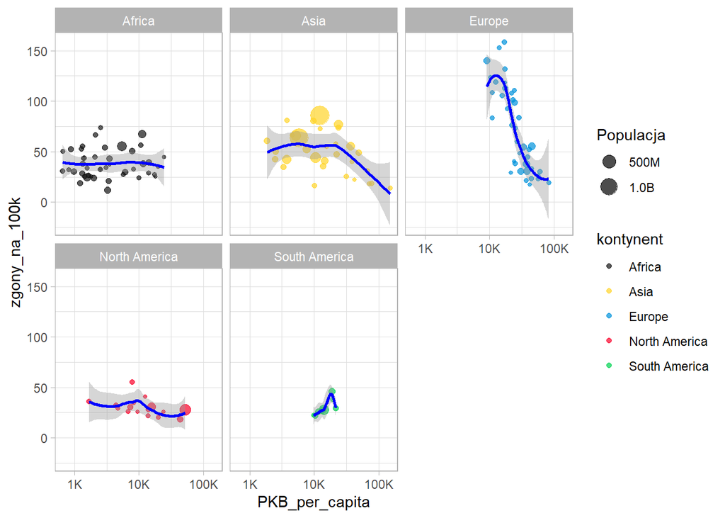

```r
dane_kompletne%>%
  filter(rok == 2016, płeć == "Both sexes",kontynent != "Oceania")%>%
  ggplot(aes(x = PKB_per_capita, y = zgony_na_100k, label= kraj))+
  scale_x_log10(labels = label_number(scale_cut = cut_short_scale()))+
  scale_y_continuous(labels = comma_format())+
  geom_point(aes(color = kontynent, size = populacja), alpha = 0.7)+
  geom_smooth(color = "blue")+
  facet_wrap(vars(kontynent))+
  scale_colour_manual(values = continent_colors)+
  scale_size_continuous(labels = label_number(scale_cut = cut_short_scale()), name = "Populacja")+
  theme_light()
```

Najbardziej odznacza się Europa gdzie widzimy, że kraje o niskim PKB na mieszkańca (ok 10 tyś. USD) mają najwyższe wskaźniki z wysztkich kontynentów i wraz z bogactwem drastycznie spada. Podobnie widzimy, że w Azji od pewnego poziomu zamożności sada wskaźnik śmiertelności.

Sprawdzmy zatem jaka jest zaeżność dla Europy.

```r
x <- dane_kompletne%>%
  filter(rok == 2016, kontynent == "Europe", płeć == "Both sexes")%>%
  select(zgony_na_100k, PKB_per_capita)

cor.test(x$zgony_na_100k, x$PKB_per_capita, method="spearman")
```

```
##
##  Spearman's rank correlation rho
##
## data:  x$zgony_na_100k and x$PKB_per_capita
## S = 18166, p-value < 2.2e-16
## alternative hypothesis: true rho is not equal to 0
## sample estimates:
##       rho
## -0.838664
```

Możemy dostrzec, że korelacja dobrobytu do śmiertelności wynosi aż -0.84. W definitywny sposób możemy określić, że kraje w Europie o wysokim PKB na osobę mają mniejszą śmiertelność niż uboższe kraje.